## Course: COMPUTATIONAL THINKING FOR GOVERNANCE ANALYTICS

### Prof. José Manuel Magallanes, PhD

- Visiting Professor of Computational Policy at Evans School of Public Policy and Governance, and eScience Institute Senior Data Science Fellow, University of Washington.
- Professor of Government and Political Methodology, Pontificia Universidad Católica del Perú.

# Basic Modeling in R

Collect the data about democracy that we prepared in Python:

```r
# clean memory
rm(list = ls())

#link To file
link='https://github.com/EvansDataScience/CTforGA_DimensionReduction/raw/main/fromPyPlus.RDS'
# a RDS file from the web needs:
myFile=url(link)

# reading in data:
multidata=readRDS(file = myFile)

# reset indexes to R format:
row.names(multidata)=NULL
```

Verifying data structure:

```r
str(multidata,width = 70,strict.width='cut')
```

```
## 'data.frame':    141 obs. of  31 variables:
##  $ Countryname                 : chr  "Afghanistan" "Albania" "Alge"..
##  $ Officialstatename           : chr  "The Islamic Republic of Afgh"..
##  $ InternetccTLD               : chr  ".af" ".al" ".dz" ".ao" ...
##  $ iso2                        : chr  "AF" "AL" "DZ" "AO" ...
##  $ iso3                        : chr  "AFG" "ALB" "DZA" "AGO" ...
##  $ Regimetype                  : Ord.factor w/ 4 levels "Authoritar"..
##  $ Overallscore                : num  0.32 6.11 3.77 3.37 6.81 5.49 ..
##  $ Electoralprocessandpluralism: num  0 7 3.08 1.33 9.17 7.5 10 9.58..
##  $ Functioningofgovernment     : num  0.07 6.43 2.5 2.86 5 5.71 8.57..
##  $ Politicalparticipation      : num  0 4.44 4.44 5 7.22 6.11 7.78 8..
##  $ Politicalculture            : num  1.25 5.63 5 5 5 3.13 8.75 6.88..
##  $ Civilliberties              : num  0.29 7.06 3.82 2.65 7.65 5 9.4..
##  $ Total                       : num  8.99 4.48 6.01 7.62 3.55 ...
##  $ X1ExternalIntervention      : num  8.3 6.1 3.7 4.6 4.3 7 0.5 0.5 ..
```

[output cut: 17 more lines]

# R for Regression

## Continuous outcome

Generally speaking, we use regression when we have a continuous value as the dependent variable, and a set of independent variables (of different types).

### * **EXPLANATORY APPROACH**

1. State hypotheses:

Prepare your hypotheses:

```r
# hypothesis 1: democracy is related to the level of security apparatus:
hypo1=formula(Demo_efa~ C1SecurityApparatus)

# hypothesis 2: democracy is related to the levels of security apparatus, and economic inequality:

hypo2=formula(Demo_efa~ C1SecurityApparatus + P1StateLegitimacy)

# hypothesis 3: democracy is related to the levels of security apparatus, economic inequality, and human rights:

hypo3=formula(Demo_efa~ C1SecurityApparatus + P1StateLegitimacy + P3HumanRights)
```

2. Compute regression models:

```r
#
# results
gauss1=glm(hypo1,
           data = multidata,
           family = 'gaussian')

gauss2=glm(hypo2,
           data = multidata,
           family = 'gaussian')

gauss3=glm(hypo3,
           data = multidata,
           family = 'gaussian')
```

3. See results:
- Test of first Hypothesis

```r
summary(gauss1)
```

```
##
## Call:
## glm(formula = hypo1, family = "gaussian", data = multidata)
##
## Deviance Residuals:
##    Min      1Q  Median      3Q     Max
## -6.184  -1.180   0.578   1.592   4.141
##
## Coefficients:
##                     Estimate Std. Error t value Pr(>|t|)
## (Intercept)          8.56487    0.48008  17.841  < 2e-16 ***
## C1SecurityApparatus -0.46679    0.08541  -5.465 2.08e-07 ***
## ---
## Signif. codes:  0 '***' 0.001 '**' 0.01 '*' 0.05 '.' 0.1 ' ' 1
##
## (Dispersion parameter for gaussian family taken to be 5.354375)
##
##     Null deviance: 904.19  on 140  degrees of freedom
## Residual deviance: 744.26  on 139  degrees of freedom
## AIC: 640.71
##
## Number of Fisher Scoring iterations: 2
```

- Test of second Hypothesis

```r
summary(gauss2)
```

```
##
## Call:
## glm(formula = hypo2, family = "gaussian", data = multidata)
##
## Deviance Residuals:
##     Min       1Q   Median       3Q      Max
## -4.2206  -0.9642  -0.1977   0.9502   3.9946
##
## Coefficients:
##                     Estimate Std. Error t value Pr(>|t|)
## (Intercept)          9.28989    0.32941  28.202  < 2e-16 ***
## C1SecurityApparatus  0.35170    0.08583   4.097 7.09e-05 ***
## P1StateLegitimacy   -0.87771    0.06810 -12.888  < 2e-16 ***
## ---
## Signif. codes:  0 '***' 0.001 '**' 0.01 '*' 0.05 '.' 0.1 ' ' 1
##
## (Dispersion parameter for gaussian family taken to be 2.447379)
##
##     Null deviance: 904.19  on 140  degrees of freedom
## Residual deviance: 337.74  on 138  degrees of freedom
## AIC: 531.31
##
## Number of Fisher Scoring iterations: 2
```

- Test of third Hypothesis:

```r
summary(gauss3)
```

```
##
## Call:
## glm(formula = hypo3, family = "gaussian", data = multidata)
##
## Deviance Residuals:
##     Min       1Q   Median       3Q      Max
## -3.9208  -0.9587  -0.2606   0.9463   4.4384
##
## Coefficients:
##                     Estimate Std. Error t value Pr(>|t|)
## (Intercept)          9.44339    0.30845  30.616  < 2e-16 ***
## C1SecurityApparatus  0.48029    0.08446   5.687 7.51e-08 ***
## P1StateLegitimacy   -0.52058    0.09886  -5.266 5.27e-07 ***
## P3HumanRights       -0.53671    0.11398  -4.709 6.03e-06 ***
## ---
## Signif. codes:  0 '***' 0.001 '**' 0.01 '*' 0.05 '.' 0.1 ' ' 1
##
## (Dispersion parameter for gaussian family taken to be 2.121829)
##
##     Null deviance: 904.19  on 140  degrees of freedom
## Residual deviance: 290.69  on 137  degrees of freedom
## AIC: 512.15
##
## Number of Fisher Scoring iterations: 2
```

You may want to see the R-squared values for each regression:

```r
library(rsq)
rsq(gauss1,adj=T); rsq(gauss2,adj=T); rsq(gauss3,adj=T)
```

```
## [1] 0.1709533
```

```
## [1] 0.6210592
```

```
## [1] 0.6714658
```

You the the last to ones have a better R-squared value than the first one. The question remains if the third is significantly better than the second one.

4. Looking for *better* model:

```r
anova(gauss1,gauss2,gauss3,test="Chisq")
```

```
## Analysis of Deviance Table
##
## Model 1: Demo_efa ~ C1SecurityApparatus
## Model 2: Demo_efa ~ C1SecurityApparatus + P1StateLegitimacy
## Model 3: Demo_efa ~ C1SecurityApparatus + P1StateLegitimacy + P3HumanRights
##   Resid. Df Resid. Dev Df Deviance  Pr(>Chi)
## 1       139     744.26
## 2       138     337.74  1   406.52 < 2.2e-16 ***
## 3       137     290.69  1    47.05 2.491e-06 ***
## ---
## Signif. codes:  0 '***' 0.001 '**' 0.01 '*' 0.05 '.' 0.1 ' ' 1
```

The second model is better than the first one; however, the third is significantly better than the previous two. You should keep the third one.

5. Verify the situation of chosen model:

5.1. Linearity between dependent variable and predictors is assumed, then these dots should follow a linear and horizontal trend:

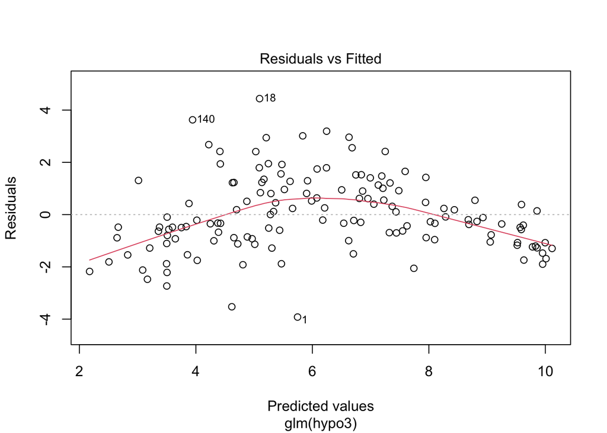

```r
plot(gauss3,1)
```

5.2. Normality of residuals is assumed:

Visual exploration:

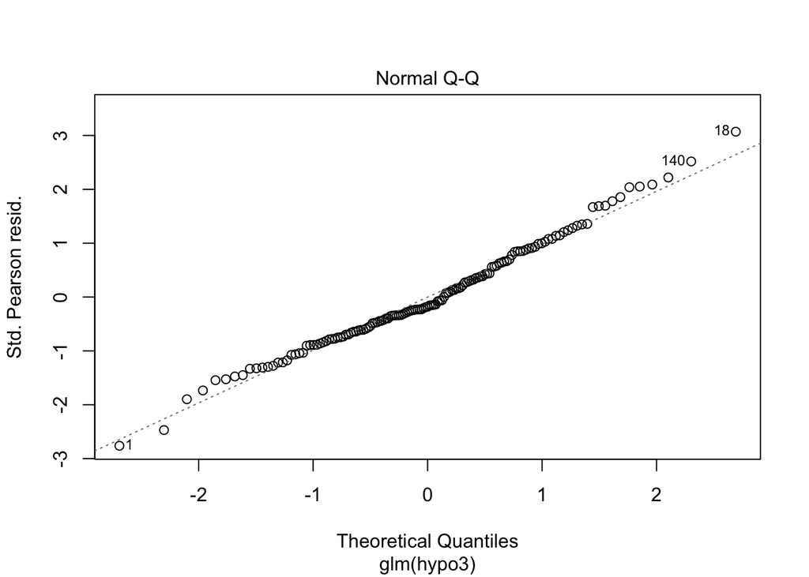

```r
plot(gauss3,2)
```

Mathematical exploration:

```r
# normality holds if the p-value is above 0.05
shapiro.test(gauss3$residuals)
```

```
##
##  Shapiro-Wilk normality test
##
## data:  gauss3$residuals
## W = 0.9875, p-value = 0.2335
```

5.3. Homoscedasticity is assumed, so you need to check if residuals are spread equally along the ranges of predictors:

Visual exploration:

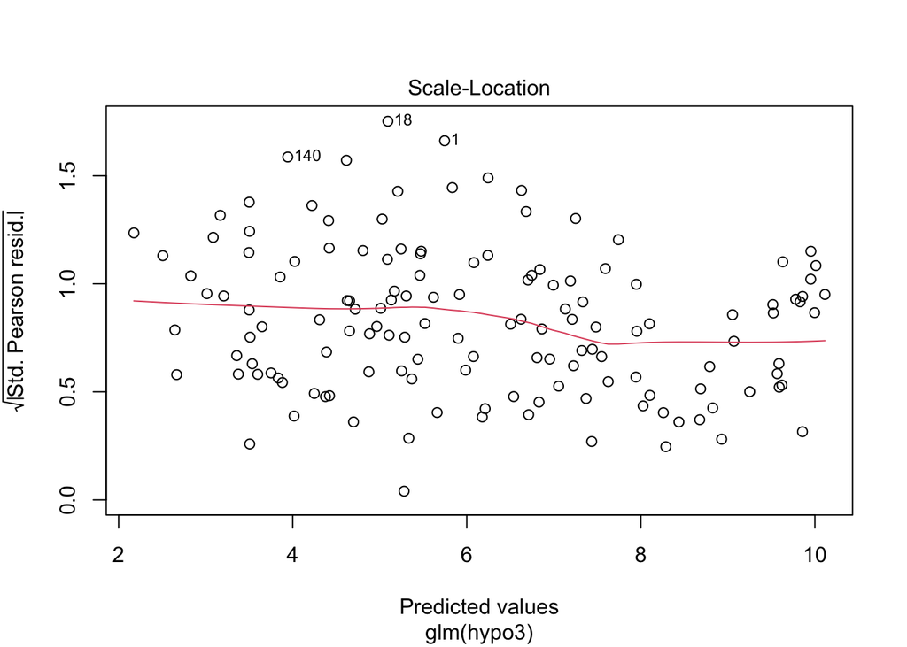

```r
plot(gauss3, 3)
```

Mathematical exploration:

```r
library(lmtest)
#if pvalue<0.05 you cannot assume Homoscedasticity
bptest(gauss3)
```

```
##
##  studentized Breusch-Pagan test
##
## data:  gauss3
## BP = 7.7829, df = 3, p-value = 0.05072
```

5.4. We assume that there is no colinearity, that is, that the predictors are not highly correlated.

```r
library(car)
vif(gauss3) # lower than 5 is desirable
```

```
## C1SecurityApparatus   P1StateLegitimacy       P3HumanRights
##            2.467505            5.370404            5.755008
```

5.5. Analize the effect of atypical values. Determine if outliers (points that are far from the rest, but still in the trend) or high-leverage points (far from the trend) are influential:

Visual exploration:

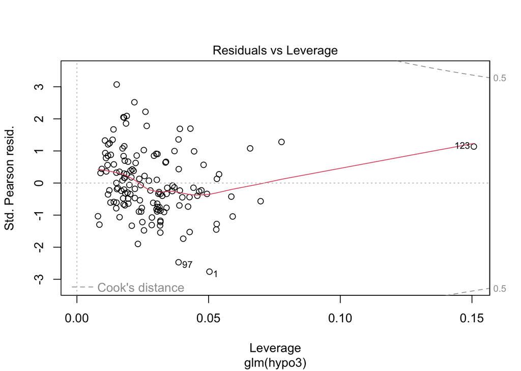

```r
plot(gauss3,5)
```

Querying:

```r
gaussInf=as.data.frame(influence.measures(gauss3)$is.inf)
gaussInf[gaussInf$cook.d,]
```

```
## [1] dfb.1_   dfb.C1SA dfb.P1SL dfb.P3HR dffit    cov.r    cook.d   hat
## <0 rows> (or 0-length row.names)
```

6. Finally, a nice summary plot of your work:

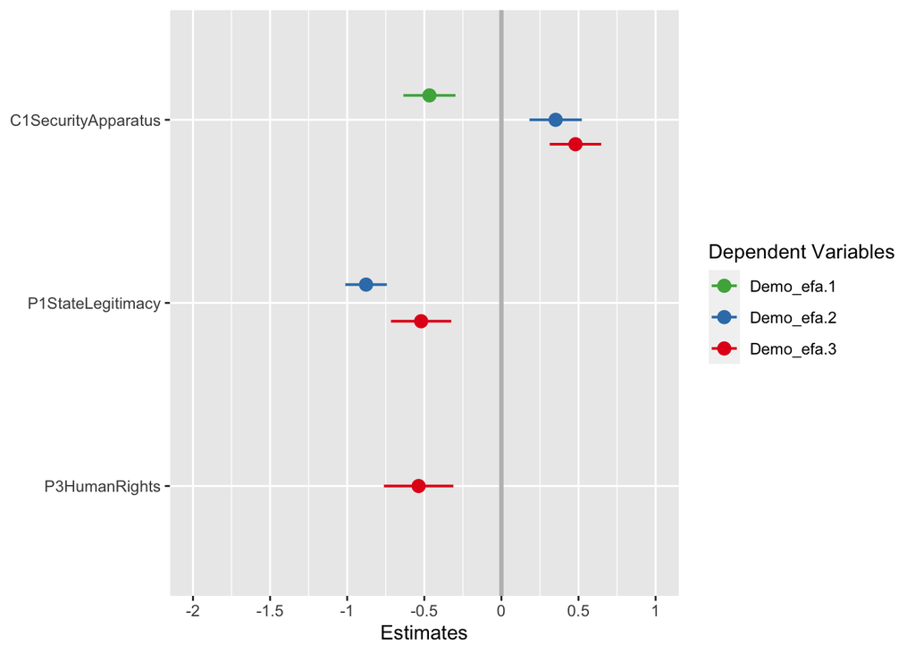

```r
library(sjPlot)
plot_models(gauss1,gauss2,gauss3,vline.color = "grey")
```

- **PREDICTIVE APPROACH**
1. Split the data set:

```r
library(caret)
set.seed(123)

# selects some rows
selection = createDataPartition(multidata$Demo_efa,
                                p = 0.75,
                                list = FALSE)
# keep only selected
trainGauss = multidata[ selection, ]

#keep all but selected
testGauss  = multidata[-selection, ]
```

2. Regress with train data

Let’s use **cross validation**: applying the regression to several samples (here 5) from the training data set:

```r
ctrl = trainControl(method = 'cv', #cross validation
                    number = 5)

gauss3CV = train(hypo3,
                 data = trainGauss,
                 method = 'glm',
                 trControl = ctrl)

gauss3CV
```

```
## Generalized Linear Model
##
## 108 samples
##   3 predictor
##
## No pre-processing
## Resampling: Cross-Validated (5 fold)
## Summary of sample sizes: 84, 88, 88, 85, 87
## Resampling results:
##
##   RMSE      Rsquared   MAE
##   1.568452  0.6383765  1.273298
```

Just checking the Rsquared you find a value better than 0.5, which is good enough.

3. Evaluate performance

```r
predictedVal<-predict(gauss3CV,testGauss)

postResample(obs = testGauss$Demo_efa,
             pred=predictedVal)
```

```
##      RMSE  Rsquared       MAE
## 1.0729395 0.7953843 0.8667255
```

From the information above, you find a good Rsquared.

## Binary outcome

In this situation you have binary dependent variable, which we do not currently have, let’s create one:

```r
multidata$Demo_dico=ifelse(multidata$Demo_efa>median(multidata$Demo_efa,
                                                   na.rm = T),
                         yes=1,
                         no=0)
```

### * **EXPLANATORY APPROACH**

1. State hypothesis:

Let’s use the same ones:

```r
hypoDico1=formula(Demo_dico~ C1SecurityApparatus)
hypoDico2=formula(Demo_dico~ C1SecurityApparatus + P1StateLegitimacy)
hypoDico3=formula(Demo_dico~ C1SecurityApparatus + P1StateLegitimacy + P3HumanRights)
```

2. Reformat

```r
multidata$Demo_dico=factor(multidata$Demo_dico)
```

6. Compute regression models:

```r
Logi1=glm(hypoDico1,data = multidata,
          family = "binomial")
Logi2=glm(hypoDico2,data = multidata,
          family = "binomial")
Logi3=glm(hypoDico3,data = multidata,
          family = "binomial")
```

7. See results:
- First Hypothesis test:

```r
summary(Logi1)
```

```
##
## Call:
## glm(formula = hypoDico1, family = "binomial", data = multidata)
##
## Deviance Residuals:
##     Min       1Q   Median       3Q      Max
## -2.1053  -0.9704  -0.4348   0.9420   1.8887
##
## Coefficients:
##                     Estimate Std. Error z value Pr(>|z|)
## (Intercept)          2.43267    0.53548   4.543 5.55e-06 ***
## C1SecurityApparatus -0.47439    0.09625  -4.929 8.27e-07 ***
## ---
## Signif. codes:  0 '***' 0.001 '**' 0.01 '*' 0.05 '.' 0.1 ' ' 1
##
## (Dispersion parameter for binomial family taken to be 1)
##
##     Null deviance: 195.46  on 140  degrees of freedom
## Residual deviance: 163.94  on 139  degrees of freedom
## AIC: 167.94
##
## Number of Fisher Scoring iterations: 3
```

- Second Hypothesis test:

```r
summary(Logi2)
```

```
##
## Call:
## glm(formula = hypoDico2, family = "binomial", data = multidata)
##
## Deviance Residuals:
##     Min       1Q   Median       3Q      Max
## -2.1975  -0.5525  -0.1979   0.4821   2.3233
##
## Coefficients:
##                     Estimate Std. Error z value Pr(>|z|)
## (Intercept)           4.7047     0.9157   5.138 2.78e-07 ***
## C1SecurityApparatus   0.2048     0.1521   1.347    0.178
## P1StateLegitimacy    -0.9870     0.1741  -5.669 1.44e-08 ***
## ---
## Signif. codes:  0 '***' 0.001 '**' 0.01 '*' 0.05 '.' 0.1 ' ' 1
##
## (Dispersion parameter for binomial family taken to be 1)
##
##     Null deviance: 195.46  on 140  degrees of freedom
## Residual deviance: 105.54  on 138  degrees of freedom
## AIC: 111.54
##
## Number of Fisher Scoring iterations: 5
```

- Third Hypothesis test:

```r
summary(Logi3)
```

```
##
## Call:
## glm(formula = hypoDico3, family = "binomial", data = multidata)
##
## Deviance Residuals:
##     Min       1Q   Median       3Q      Max
## -2.0910  -0.4767  -0.1331   0.4658   2.2672
##
## Coefficients:
##                     Estimate Std. Error z value Pr(>|z|)
## (Intercept)           5.0866     0.9556   5.323 1.02e-07 ***
## C1SecurityApparatus   0.4184     0.1862   2.247 0.024640 *
## P1StateLegitimacy    -0.6760     0.2052  -3.294 0.000986 ***
## P3HumanRights        -0.6183     0.2267  -2.728 0.006380 **
## ---
## Signif. codes:  0 '***' 0.001 '**' 0.01 '*' 0.05 '.' 0.1 ' ' 1
##
## (Dispersion parameter for binomial family taken to be 1)
##
##     Null deviance: 195.460  on 140  degrees of freedom
## Residual deviance:  97.279  on 137  degrees of freedom
## AIC: 105.28
##
## Number of Fisher Scoring iterations: 6
```

8. Search for better model:

```r
lmtest::lrtest(Logi1,Logi2,Logi3)
```

```
## Likelihood ratio test
##
## Model 1: Demo_dico ~ C1SecurityApparatus
## Model 2: Demo_dico ~ C1SecurityApparatus + P1StateLegitimacy
## Model 3: Demo_dico ~ C1SecurityApparatus + P1StateLegitimacy + P3HumanRights
##   #Df  LogLik Df   Chisq Pr(>Chisq)
## 1   2 -81.971
## 2   3 -52.769  1 58.4038  2.135e-14 ***
## 3   4 -48.639  1  8.2593   0.004054 **
## ---
## Signif. codes:  0 '***' 0.001 '**' 0.01 '*' 0.05 '.' 0.1 ' ' 1
```

The third hypothesis would hold again.

9. Verify the situation of chosen model

9.1. Linearity assumption (Box-Tidwell test)

```r
multidata$secuTEST=multidata$C1SecurityApparatus*log(multidata$C1SecurityApparatus)
multidata$legitTEST=multidata$P1StateLegitimacy*log(multidata$P1StateLegitimacy)
multidata$humanTEST=multidata$P3HumanRights*log(multidata$P3HumanRights)

DicoTest=formula(Demo_dico~ C1SecurityApparatus + P1StateLegitimacy + P3HumanRights + secuTEST + legitTEST + humanTEST)

summary(glm(DicoTest,data=multidata,family = binomial))
```

```
##
## Call:
## glm(formula = DicoTest, family = binomial, data = multidata)
##
## Deviance Residuals:
##     Min       1Q   Median       3Q      Max
## -2.3440  -0.4663  -0.1371   0.2621   2.4536
##
## Coefficients:
##                     Estimate Std. Error z value Pr(>|z|)
## (Intercept)           9.0753     5.0448   1.799   0.0720 .
## C1SecurityApparatus   3.6578     1.7234   2.122   0.0338 *
## P1StateLegitimacy     0.8918     1.7559   0.508   0.6115
## P3HumanRights        -7.0642     2.9445  -2.399   0.0164 *
## secuTEST             -1.2319     0.6389  -1.928   0.0538 .
## legitTEST            -0.6338     0.6539  -0.969   0.3325
## humanTEST             2.4146     1.0589   2.280   0.0226 *
## ---
## Signif. codes:  0 '***' 0.001 '**' 0.01 '*' 0.05 '.' 0.1 ' ' 1
##
## (Dispersion parameter for binomial family taken to be 1)
##
##     Null deviance: 195.460  on 140  degrees of freedom
## Residual deviance:  87.691  on 134  degrees of freedom
## AIC: 101.69
##
## Number of Fisher Scoring iterations: 7
```

From the table above, your main concern should be the significant TEST variables.

9.2. We assume that there is no colinearity, that is, that the predictors are not correlated.

```r
vif(Logi3)
```

```
## C1SecurityApparatus   P1StateLegitimacy       P3HumanRights
##            2.193035            2.097938            2.413427
```

9.3 Analize the effect of atypical values. Determine if outliers (points that are far from the rest, but still in the trend) or high-leverage points (far from the trend but close to the rest) are influential:

Visual exploration:

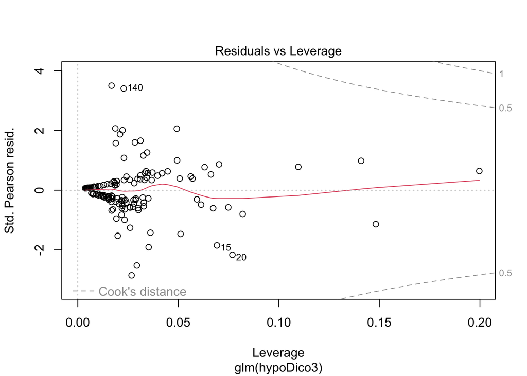

```r
plot(Logi3,5)
```

10. Finally, a nice summary plot of your work by computing the marginal effects:

```r
library(margins)
(modelChosen = margins(Logi3))
```

```
## Average marginal effects
```

```
## glm(formula = hypoDico3, family = "binomial", data = multidata)
```

```
##  C1SecurityApparatus P1StateLegitimacy P3HumanRights
##              0.04491          -0.07256      -0.06637
```

```r
(margins=summary(modelChosen))
```

```
##               factor     AME     SE       z      p   lower   upper
##  C1SecurityApparatus  0.0449 0.0188  2.3833 0.0172  0.0080  0.0818
##    P1StateLegitimacy -0.0726 0.0190 -3.8126 0.0001 -0.1099 -0.0353
##        P3HumanRights -0.0664 0.0219 -3.0316 0.0024 -0.1093 -0.0235
```

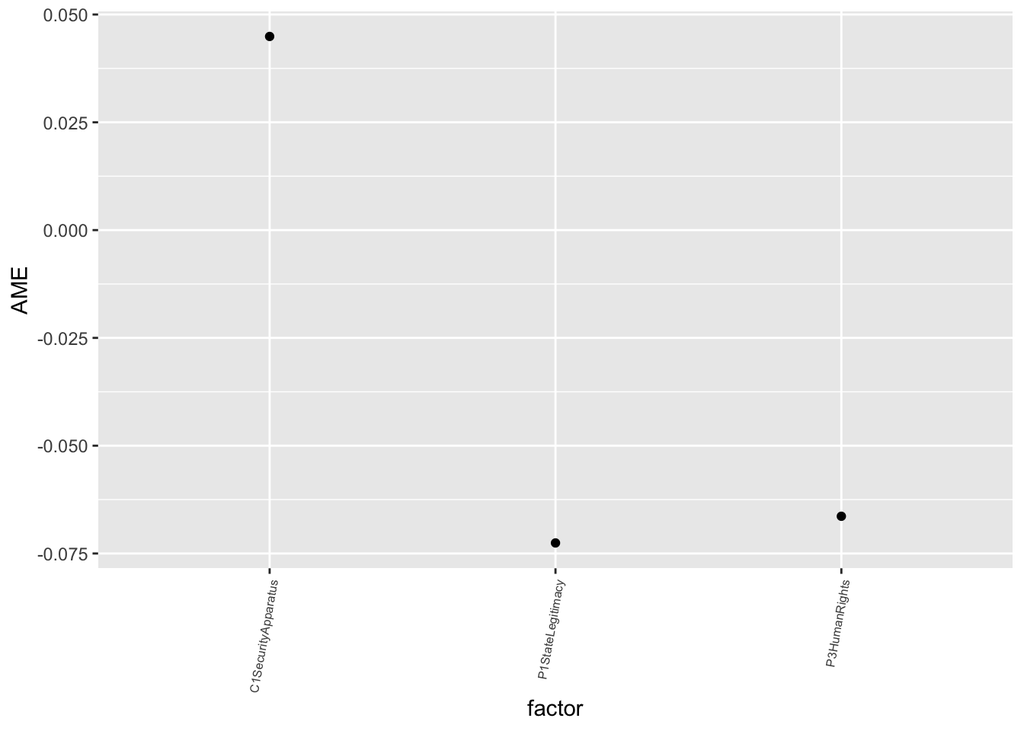

```r
base= ggplot(margins,aes(x=factor, y=AME)) + geom_point()
plot2 = base + theme(axis.text.x = element_text(angle = 80,
                                              size = 6,
                                              hjust = 1))
plot2
```

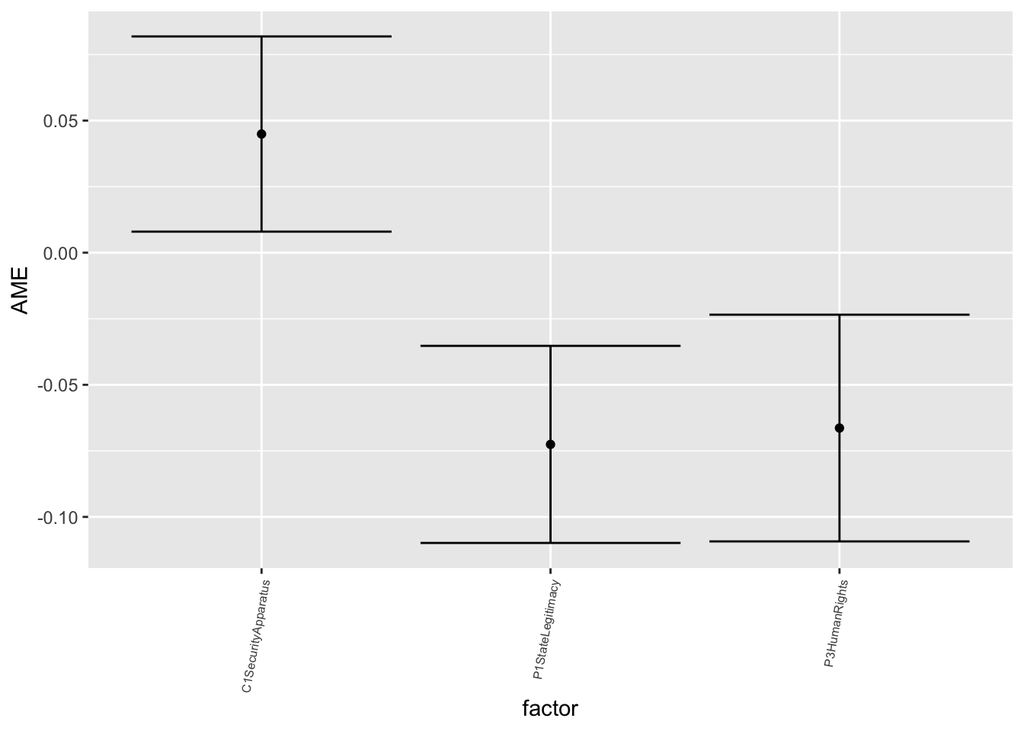

```r
plot2 +  geom_errorbar(aes(ymin=lower, ymax=upper))
```

### * **PREDICTIVE APPROACH**

1. Split the data set:

```r
set.seed(123)

selection = createDataPartition(multidata$Demo_dico,
                                p = 0.75,
                                list = FALSE)
trainLogi = multidata[selection, ]
testLogi  = multidata[-selection, ]
```

2. Regress with train data

Let’s use cross validation, applying the regression to five samples from the training data set:

```r
set.seed(123)
ctrl = trainControl(method = 'cv',number = 5)

Logis3CV = train(hypoDico3,
                 data = trainLogi,
                 method = 'glm',
                 family="binomial",
                 trControl = ctrl)
```

3. See results:

```r
Logis3CV
```

```
## Generalized Linear Model
##
## 107 samples
##   3 predictor
##   2 classes: '0', '1'
##
## No pre-processing
## Resampling: Cross-Validated (5 fold)
## Summary of sample sizes: 86, 85, 85, 87, 85
## Resampling results:
##
##   Accuracy   Kappa
##   0.8128139  0.6254545
```

3. Evaluate performance

3.1 Get predictions on test data

```r
predictions = predict(Logis3CV,
                      newdata=testLogi,
                      type='raw')
```

3.2 Assess performance

```r
confusionMatrix(data=predictions,
                reference=testLogi$Demo_dico,
                positive = "1")
```

```
## Confusion Matrix and Statistics
##
##           Reference
## Prediction  0  1
##          0 15  3
##          1  2 14
##
##                Accuracy : 0.8529
##                  95% CI : (0.6894, 0.9505)
##     No Information Rate : 0.5
##     P-Value [Acc > NIR] : 1.928e-05
##
##                   Kappa : 0.7059
##
##  Mcnemar's Test P-Value : 1
##
##             Sensitivity : 0.8235
##             Specificity : 0.8824
##          Pos Pred Value : 0.8750
##          Neg Pred Value : 0.8333
##              Prevalence : 0.5000
##          Detection Rate : 0.4118
##    Detection Prevalence : 0.4706
##       Balanced Accuracy : 0.8529
##
##        'Positive' Class : 1
##
```

Here is some help for you to interpret the [result](https://docs.google.com/presentation/d/e/2PACX-1vRyFvA5U2HXC3CGBeKEr209_KLjjdeo8FoKT6BxMsjLNOJwx7YDUmGEpDq1pzfGO7Zizuk5rogUNPgj/pub?start=false&loop=false&delayms=3000).